# Regression Analysis - STAT482 - HW #1

Alex Towell (atowell@siue.edu)

Refer to the data from Exercise 1.27

A person’s muscle mass is expected to decrease with age. To explore this relationship in women, a nutritionist randomly selected $15$ women for each $10$ year age group, beginning with $40$ and ending with age $79$. The input variable $x$ is age (in years), and the response variable $y$ is muscle mass (in muscle mass units).

# Part (1)

The data is given by $(x_1,y_1),\ldots,(x_n,y_n)$ and, we assume, it at least approximately comes from the model given by
$$Y_i = \beta_0 + \beta_1 x_i + \epsilon_i$$
for $i=1,\ldots,n$ where $\epsilon_i \stackrel{\text{iid}}{\sim} N(0,\sigma^2)$.

Therefore, $Y_1,\ldots,Y_n$ are independently distributed with a variance $\sigma^2$ and a conditional expectation
$$E(Y_i|x_i) = \beta_0 + \beta_1 x_i$$
at the given input level $x_i$ for $i=1,\ldots,n$.

# Part (2)

$\beta_1$ is the difference in the mean muscle mass from a $1$ year increase in age. In other words, for every $1$ year increase in age $(x)$, the mean muscle mass decreases by $\beta_1$ units. (Note that since we expect a negative correlation between age and muscle mass, $\beta_1$ is expected to be negative.)

# Part (3)

We populate the data frame for exercise 1.27 with the following:

```r
# the tabulated data is provided by the file accompanying file named 'CH01PR27.txt'.
# the original URL for this data is:
#     http://users.stat.ufl.edu/~rrandles/sta4210/Rclassnotes/data/textdatasets/KutnerData/Chapter%20%201%20Data%20Sets/CH01PR27.txt
mass.data = read.table('CH01PR27.txt')
colnames(mass.data)=c("mass","age")
```

We use R’s built-in function $\operatorname{lm}$ to perform the simple linear regression.

```r
# the model for muscle mass, mass[i] = beta0 + beta1 * age[i] + e[i]
# where e[i] ~ N(0,sigma2).
mass.mod = lm(mass ~ age, data=mass.data)
mass.mod
```

```
##
## Call:
## lm(formula = mass ~ age, data = mass.data)
##
## Coefficients:
## (Intercept)          age
##      156.35        -1.19
```

```r
b0 = round(mass.mod$coefficients[1],digits=2); names(b0) = NULL
b1 = round(mass.mod$coefficients[2],digits=2); names(b1) = NULL
c("b0"=b0,"b1"=b1)
```

```
##     b0     b1
## 156.35  -1.19
```

We see that $b_0 = 156.35$ and $b_1 = -1.19$, and thus our estimate of $E(Y|x)$ is given by
$$\hat{Y}_i = 156.35 - 1.19 x_i.$$

# Part (4)

We show two methods to obtain the variance and standard deviation.

## Method 1

First, we may use R’s built-in method:

```r
sigma.hat = summary(mass.mod)$sigma
sigma2.hat = sigma.hat^2
c("sigma.hat"=sigma.hat,"sigma.hat^2"=sigma2.hat)
```

```
##   sigma.hat sigma.hat^2
##    8.173177   66.800819
```

We see that $\hat\sigma^2 = 66.8008189$ and $\hat\sigma = 8.1731768$. Thus, an estimate of the conditional generative model for $Y_i$ given $x_i$ is given by
$$\hat{Y}_i = 156.35 - 1.19 x_i + \hat\epsilon_i$$
where $\hat\epsilon_i \stackrel{\text{iid}}{\sim} \mathcal{N}(0,66.8008189)$ whose expectation is $E(\hat{Y_i}|x_i) = 156.35 - 1.19 x_i$.

## Method 2

A second approach to estimating $\sigma^2$ and $\sigma$ is given by the following R code:

```r
resid = mass.mod$residuals
n = length(resid)
sse = sum(resid^2)
mse = sse / (n-2) # df = n-2
sigma2.hat = mse # estimate of sigma^2
sigma.hat = sqrt(sigma2.hat) # estimate of sigma
c("sigma.hat"=sigma.hat,"sigma.hat^2"=sigma2.hat)
```

```
##   sigma.hat sigma.hat^2
##    8.173177   66.800819
```

# Part (5)

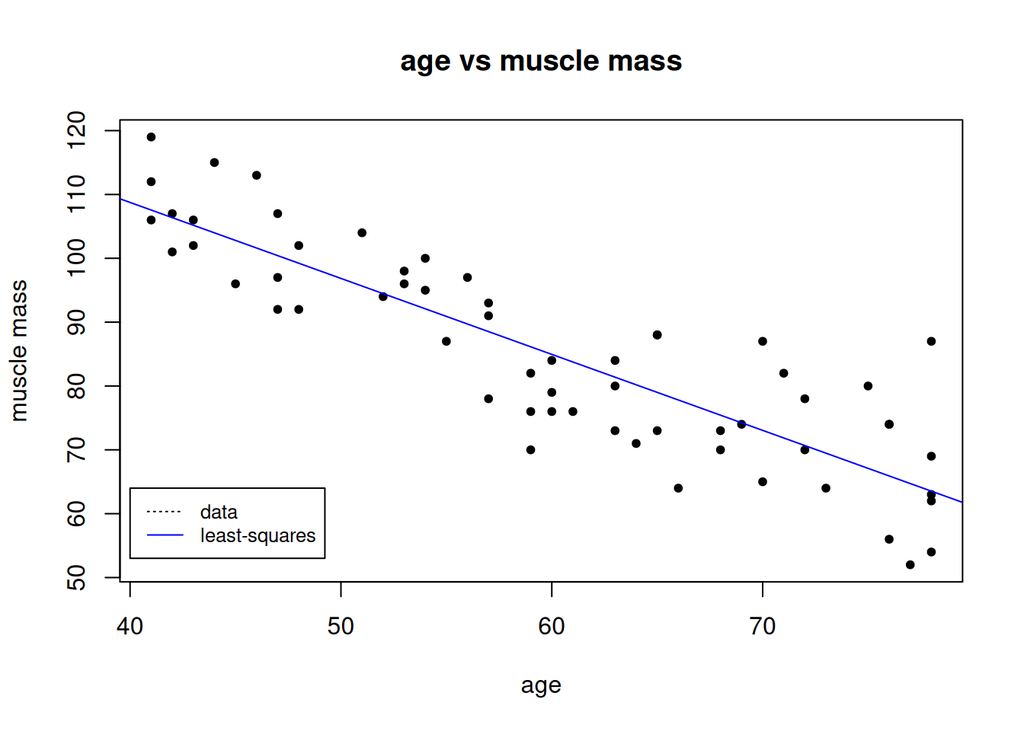

```r
plot(x=mass.data$age,
     y=mass.data$mass,
     pch=20,
     type="p",
     xlab="age",
     ylab="muscle mass",
     main="age vs muscle mass")

abline(mass.mod,col="blue")

legend(x=40, y=64,
       legend=c("data","least-squares"),
       col=c("black","blue"), lty=c("dotted","solid"),
       cex=0.8)
```

# Part (6)

From a visual inspection of the scatterplot, the amount of muscle mass shows a general linear (decreasing) trend as a function of age. Thus, a linear regression model is appropriate.

## Time series analysis

Feel free to ignore this subsection, since I explore the topic with insights from a time series class taught by Dr. Qiang, where some of the assumptions in the regression model are relaxed, e.g., the random errors term may be correlated.

We see that the data points are randomly scattered around the regression line, such that the deviations from the conditional expectation have no obvious patterns, suggesting the model has captured all significant patterns in the data leaving a white noise process as the only remaining source of uncertainty.

We show a histogram of the residuals, a scatterplot of residuals vs age, and the autocorrelation of the residuals:

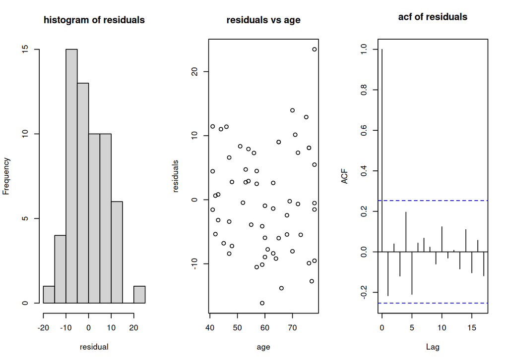

```r
par(mfrow=c(1,3))
hist(mass.mod$residuals,xlab="residual",main="histogram of residuals")
plot(x=mass.data$age,y=mass.mod$residuals,xlab="age",ylab="residuals",main="residuals vs age")
acf(mass.mod$residuals,main="acf of residuals")
```

The histogram appears compatible with the normality assumption, the scatterplot indicates the residuals are centered around $0$ with a constant variance, and the ACF plot indicates the residuals are uncorrelated.

If, say, the ACF demonstrated autocorrelation, then while the estimated regression model used previously would still provide for a good fit, the estimate of the variance would be larger than necessary compared to, say, an ARIMA model.